# Advanced bioinformatics 2023 assessment (m2207228, 19021106)

2207228(SGUL) 19021106(KCL)

2023-04-05

## General R/Rstudio assessment

Task 1: Using the sum() function and : operator, write an expression in the code snippet to evaluate the sum of all integers between 5 and 55

```r
#3.1
#creating a vector x to contain integer values between 5 and 55 specified by the : operator
x <- 5:55
sum (x) #sum of the values in x
```

```
## [1] 1530
```

Task 2: Write a function called sumfun with one input parameter, called n, that calculates the sum of all integers between 5 and n. Use the function to do the calculation for n = 10, n = 20, and n = 100 and present the results.

```r
#3.2
# creating sumfun as a function that takes the input n and gives the sum of all integers between 5 and the input numbers (10, 20 and 100)
sumfun <- function(n) {sum(5:n)}
sumfun (10)
```

```
## [1] 45
```

```r
sumfun (20)
```

```
## [1] 200
```

```r
sumfun (100)
```

```
## [1] 5040
```

Task 3: The famous Fibonacci series is calculated as the sum of the two preceding members of the sequence, where the first two steps in the sequence are 1, 1. Write an R script using a for loop to calculate and print out the first 12 entries of the Fibonacci series.

```r
#3.3
#creating fibonacci as a function that holds numeric values
Fibonacci <-numeric (12)
Fibonacci[1] <- Fibonacci [2] <-1 #to assign the first 2 elements of the fibonnaci series as 1,1
for (i in 3:12) Fibonacci[i] <- Fibonacci[i-2] + Fibonacci[i-1] #the for loop runs from the 3rd to the 12th element to give the sum of the two preceding members of the sequence
print ("The first 12 entries of the Fibonacci series:")
```

```
## [1] "The first 12 entries of the Fibonacci series:"
```

```r
print (Fibonacci) #printing the fibonacci series as the loop runs
```

```
##  [1]   1   1   2   3   5   8  13  21  34  55  89 144
```

Task 4:With the mtcars dataset bundled with R, use ggplot to generate a box of miles per gallon (in the variable mpg) as a function of the number of gears (in the variable gear). Use the fill aesthetic to colour bars by number of gears.

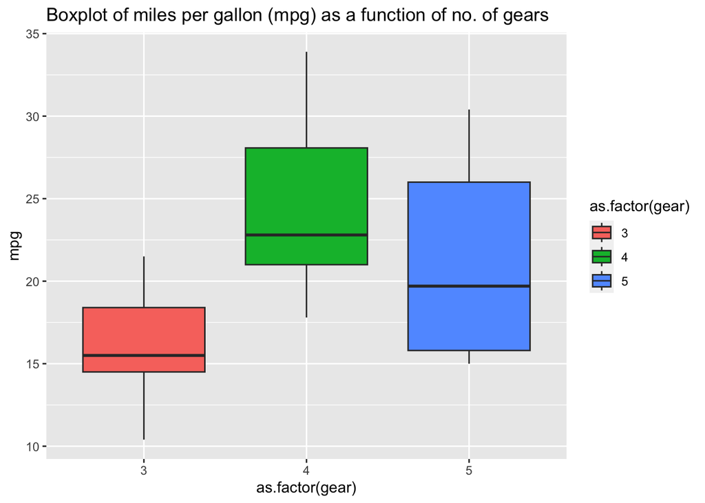

```r
#3.4
#using ggplot2
library (ggplot2)
#setting the dataset to mtcars, x axis as gear, y axis as miles per gallon(mpg), filling the boxplot bars as per number of gears
ggplot (data=mtcars, aes (x= as.factor(gear), y=mpg)) + geom_boxplot (aes(fill= as.factor(gear)))+ ggtitle ("Boxplot of miles per gallon (mpg) as a function of no. of gears")
```

Task 5: Using the cars dataset and the function lm, fit a linear relationship between speed and breaking distance in the variable distance.

```r
#3.5
#creating y1 and x1 as variables to hold speed and data from the cars dataset respectively, then using lm to get the linear relationship of x1 over y1
y1 <-cars $dist; x1 <-cars $speed; model <-lm (formula = "y1 ~ x1")
summary (model)  #gives summary stats of the linear fit
```

```
##
## Call:
## lm(formula = "y1 ~ x1")
##
## Residuals:
##     Min      1Q  Median      3Q     Max
## -29.069  -9.525  -2.272   9.215  43.201
##
## Coefficients:
##             Estimate Std. Error t value Pr(>|t|)
## (Intercept) -17.5791     6.7584  -2.601   0.0123 *
## x1            3.9324     0.4155   9.464 1.49e-12 ***
## ---
## Signif. codes:  0 '***' 0.001 '**' 0.01 '*' 0.05 '.' 0.1 ' ' 1
##
## Residual standard error: 15.38 on 48 degrees of freedom
## Multiple R-squared:  0.6511, Adjusted R-squared:  0.6438
## F-statistic: 89.57 on 1 and 48 DF,  p-value: 1.49e-12
```

Task 6: Use ggplot to plot the data points from Task 5 and the linear fit

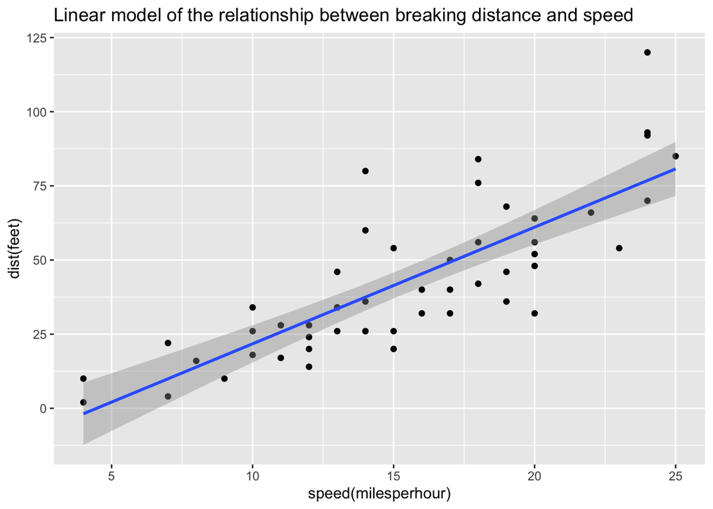

```r
#3.6
#plotting the datapoints from the previous task and the linear fit
ggplot1 <- ggplot (data= cars, aes (x= speed, y=dist)) + geom_point() + geom_smooth(method = "lm",formula = "y ~ x") + ggtitle("Linear model of the relationship between breaking distance and speed") + xlab("speed(milesperhour)")+ ylab("dist(feet)")
ggplot1
```

Task 7: Using the cars dataset, now use linear regression (lm) to estimate the average reaction time for the driver to start breaking (in seconds). Also use ggplot to plot the data points and the fitted relationship.

```r
#3.7
# create dist_miles to hold the distance converted to miles from the cars dataset
dist_miles <- cars $dist* 0.000189
# create speed_milesperhour to hold the square value of speed which is already in miles per hour
speed_milesperhour <- cars $speed^2
#linear model
lm (formula = dist_miles ~ speed_milesperhour)
```

```
##
## Call:
## lm(formula = dist_miles ~ speed_milesperhour)
##
## Coefficients:
##        (Intercept)  speed_milesperhour
##          1.675e-03           2.438e-05
```

```r
# create reac_time wich holds the time coverted from hour to  seconds (/3600) after the value of slope reaction_time is multiplied by 2 (as slope is equal to half the avg reaction time)
reac_time <- (2.438e-05 *2)/3600
#show the value of reaction time
reac_time
```

```
## [1] 1.354444e-08
```

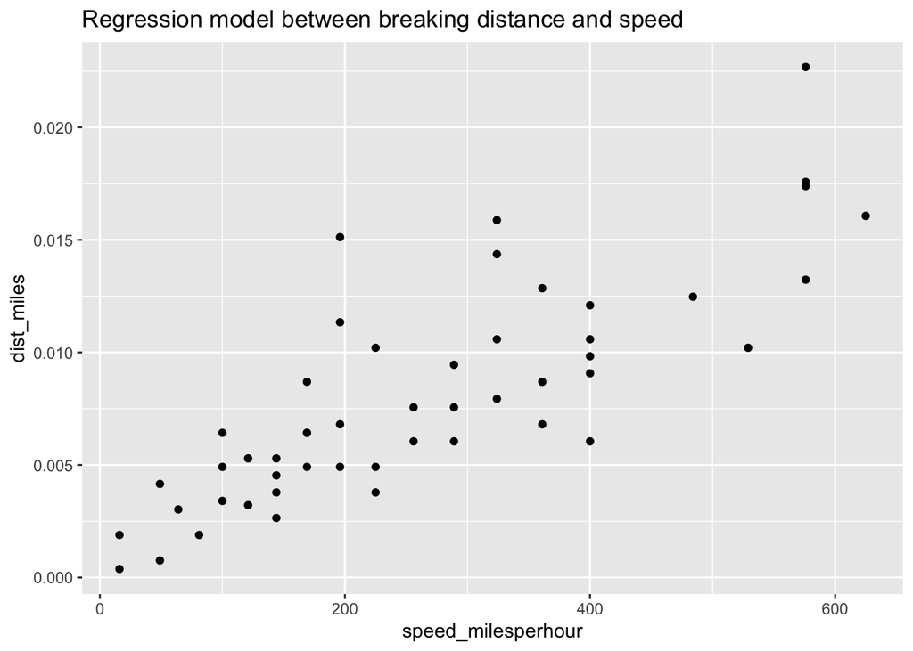

```r
#load ggplot2
library(ggplot2)
#creating a regression model using the liner fitted model plotting speed_milesperhour over dist_miles from the cars dataset
ggplot (data=cars, aes(speed_milesperhour, dist_miles)) + geom_point() + geom_smooth (method = "lm", formula = dist_miles ~ speed_milesperhour) + ggtitle ("Regression model between breaking distance and speed")
```

## RNA-seq assessment

Task 8: Read in count data and sample description

```r
#3.8
#setting the working directory first using setwd()
setwd("/Users/ishi10/Desktop/course")
# Read input file with count data using the read.csv() function
all_counts <- read.csv(file ="exercises/data/exercise1_counts.csv", row.names = 1)

# Read input file with sample description using the read.csv() function
sam_des <- read.table("exercises/data/exercise1_sample_description.info", sep = "\t", header = TRUE)
```

Task 9:Create col_data and check dimensions

```r
#3.9
# Prepare data for DESeq
#we make col_data where we input the sample, condition and batch columns from the sam_des file as a dataframe
col_data <- data.frame(sample = sam_des$sample,
                  condition = sam_des$condition,
                  batch = sam_des$batch)

# Storing the data as factors so that further analysis is easier
col_data$sample <- as.factor(col_data$sample)
col_data$condition <- as.factor(col_data$condition)
col_data$batch <- as.factor(col_data$batch)

# Check dimensions
all(colnames(all_counts) == sam_des$sample)
```

```
## [1] FALSE
```

Task 10:Construct DESeqDataSet object using count data and sample description.

```r
#3.10
#making the DESeqDataSet object
# Load DESeq2 library
library(DESeq2)
# Build DESeq dataset
dds <- DESeqDataSetFromMatrix(countData =all_counts, colData = col_data, design = ~condition)

# Apply DESeq normalization to the DESeq dataset to fot to the model and further statistical testing
dds <- DESeq(dds)
```

Task 11: Perform rlog and VST transformation on the data

```r
#3.11
#to make it easier to work with our count data we use the transformed version where ther are converted to the log2 scale normalized to library size.
# Regularized logarithm (rlog)
rld <- rlog(dds)
class(rld)
```

```
## [1] "DESeqTransform"
## attr(,"package")
## [1] "DESeq2"
```

```r
# Get rld in count format
rld_counts <- assay(rld)
class(rld_counts)
```

```
## [1] "matrix" "array"
```

```r
# Variance Stabilizing Transformation (rlog)- works in the same way as rlog but is faster and is used with longer datasets
vsd <- varianceStabilizingTransformation(dds)
class(vsd)
```

```
## [1] "DESeqTransform"
## attr(,"package")
## [1] "DESeq2"
```

```r
# Get vsd in count format
vsd_counts <- assay(vsd)
class(vsd_counts)
```

```
## [1] "matrix" "array"
```

Task 12:Draw a heatmap of count matrix based on the top 40 highly expressed genes using rlog and VST data

```r
#3.12
# Loading the pheatmap library to visualise the count matrix
library("pheatmap")

# Get dds normalized counts
dds_counts <- counts(dds, normalized = TRUE)
head(dds_counts)
```

```
##           control_FFa1.bam control_FFa2.bam control_FFa3.bam mutant_KOa1.bam
## 497097            19.13143         30.06784         0.000000        24.18065
## 100503874         23.91429          0.00000         0.000000        73.69341
## 100038431          0.00000          0.00000         1.993454         0.00000
## 19888             13.15286          0.00000         9.967268       130.11493
## 20671             16.74000         30.06784         0.000000        46.05838
## 27395            556.00730        362.69327       594.049156       502.03639
##           mutant_KOa2.bam mutant_KOa3.bam mutant_KOb1.bam mutant_KOb2.bam
## 497097           18.61164       30.191405       12.646378        0.000000
## 100503874         0.00000        4.472801        3.161594        0.000000
## 100038431         0.00000        8.945602        0.000000        0.000000
## 19888             0.00000       29.073205        8.852464        3.354392
## 20671             9.30582       36.900606       20.866523        6.708784
## 27395           797.97410      639.610508      871.335429     1062.783210
##           mutant_KOb3.bam
## 497097           1.473775
## 100503874        1.473775
## 100038431        0.000000
## 19888           11.790200
## 20671           17.685300
## 27395         1144.386319
```

```r
# Get normalized counts - 40 higher values where they are ordered in a decreasing order
select <- order(rowMeans(dds_counts), decreasing = TRUE)[1:40]
#to display from  the top
head(select)
```

```
## [1] 21373 10174 24719 21374 24718  2808
```

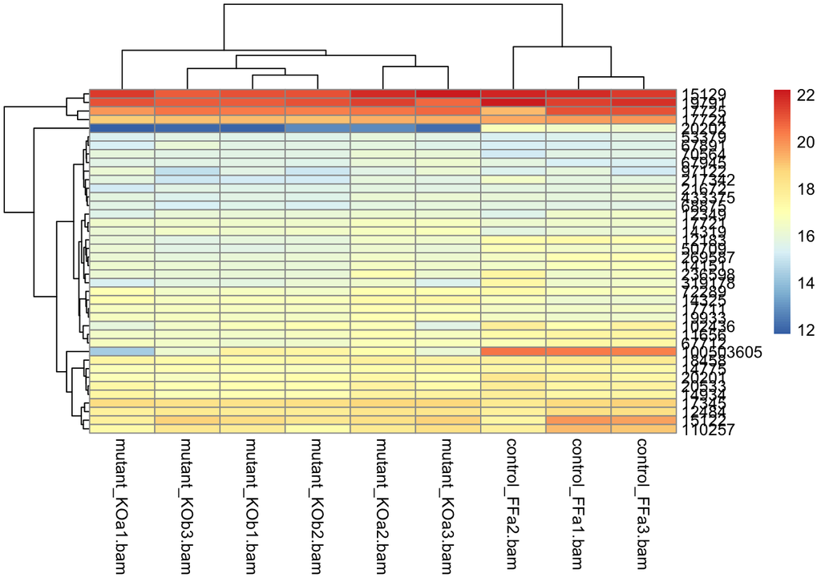

```r
# Heatmap of the rlog transformed data
pheatmap(assay(rld)[select, ])
```

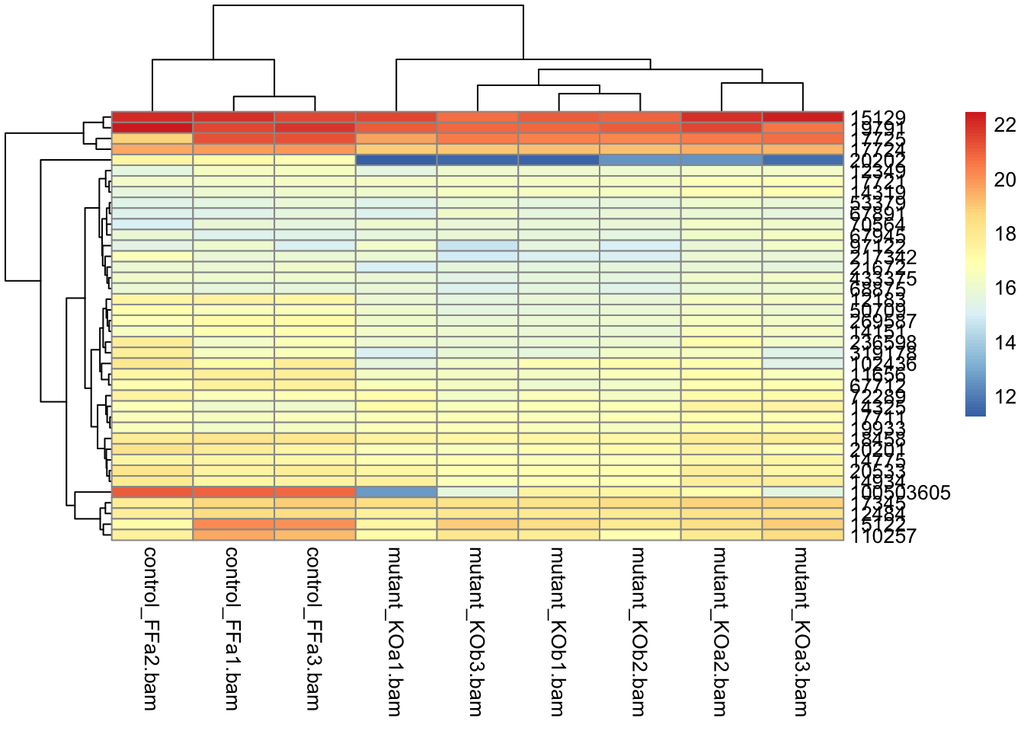

```r
# Heatmap of the vst transformed data
pheatmap(assay(vsd)[select, ])
```

Task 13: Generate a SDM to see the clustering of count data.

```r
#3.13
print("Sample Distance Matrix")
```

```
## [1] "Sample Distance Matrix"
```

```r
#this is a useful way to study the clustering observed by checking for similarity across samples (ideally replicates should group together)
# Compute SDM from rlog transformed data
#we get sample to sample distances by using the dist function to the transpose of our count matrix
sample_dist <- dist(t(assay(rld)))
class(sample_dist)
```

```
## [1] "dist"
```

```r
# Get SDM in matrix form
sdm <- as.matrix(sample_dist)
class(sdm)
```

```
## [1] "matrix" "array"
```

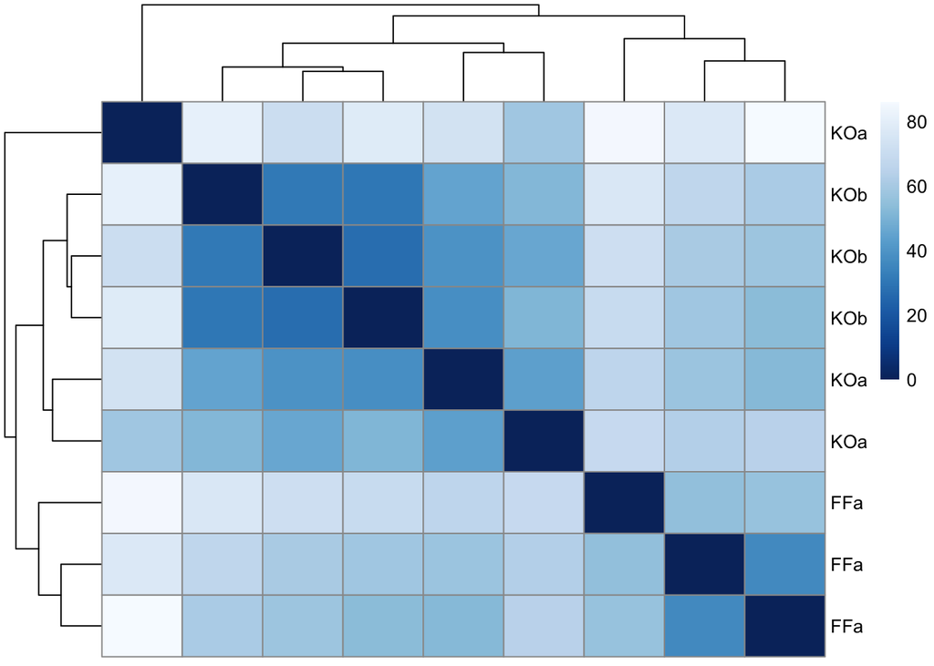

```r
# Load library
library("RColorBrewer")

# Add row names for clear plot
rownames(sdm) <- rld$condition
colnames(sdm) <- NULL

# Add colors
colors <- colorRampPalette(rev(brewer.pal(9, "Blues")))(255)

# Plot heatmap
pheatmap(sdm,
         clustering_distance_rows = sample_dist,
         clustering_distance_cols = sample_dist,
         col = colors)
```

Task 14:Perform the Principal Component Analysis using rlog method and find out the % significance values of first two principal components.

```r
#3.14
# Principal Component Analysis
print("Principal Component Analysis")
```

```
## [1] "Principal Component Analysis"
```

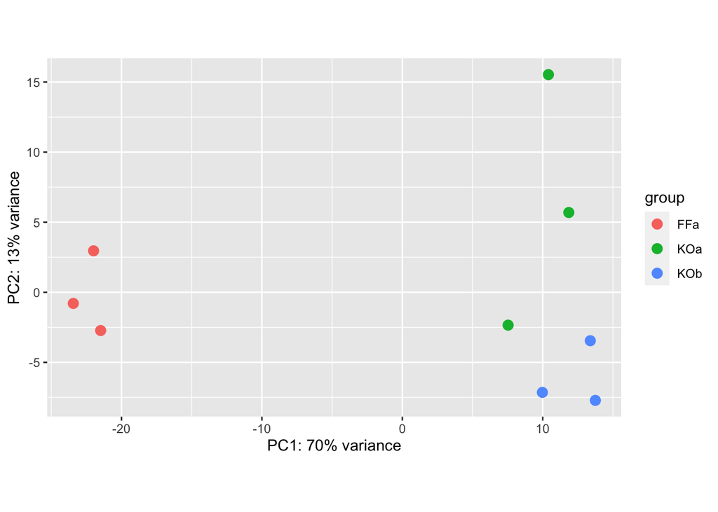

```r
# PCA plot on our rld (rlog(dds)) transformed data
plotPCA(rld, intgroup = "condition")
```

```r
# Save figure
library(ggplot2)
ggsave(file = "figures/PCA_plot_rld.png")
```

Task 15: Repeat the PCA, this time using VST method and compare the plots with the ones obtained using rlog method.

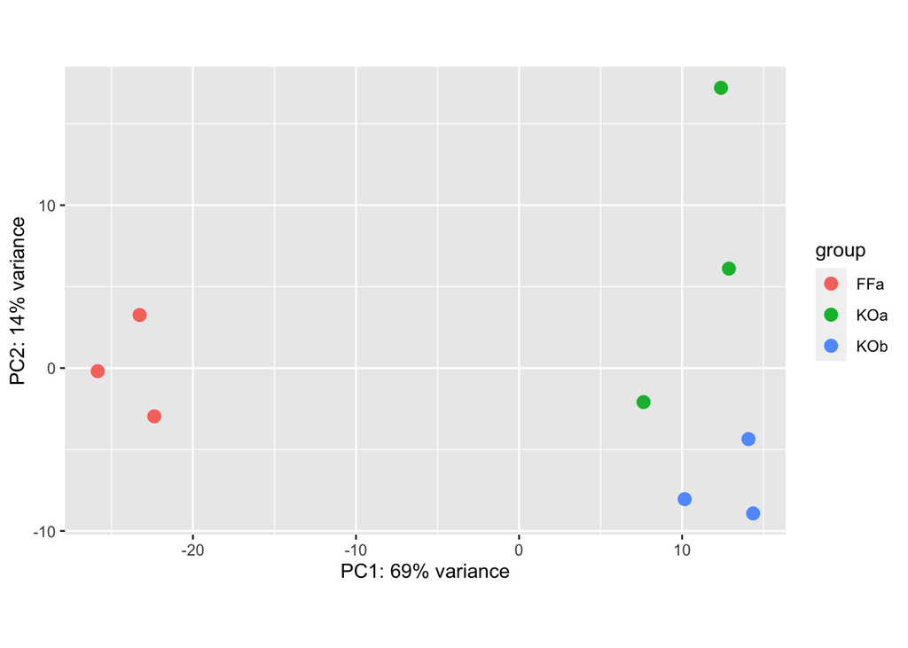

```r
#3.15
# PCA plot on our vsd (varianceStabilizingTransformation(dds)) transformed data
plotPCA(vsd, intgroup = "condition")
```

```r
# Save figure
library(ggplot2)
ggsave(file = "figures/PCA_plot_vst.png")
```

## ChIP-seq assessment

Task 16: Read in the two Myc Mel peakset replicates

```r
#3.16
#setting the working directory first using setwd()
setwd("/Users/ishi10/Desktop/course 2")
#loading the required libraries
library(ChIPQC)
library(DESeq2)

#reading in the two myc mel peakset replicates to firstPeakSet and secondPeakSet respectively using ChIPQC fucntion GetGRanges as our input files are in the MACS format which is different from bed/bed6
firstPeakSet <- ChIPQC:::GetGRanges("data/MacsPeaks/mycmelrep1_peaks.xls", sep="\t", simple=F)
secondPeakSet <- ChIPQC:::GetGRanges("data/MacsPeaks/mycmelrep2_peaks.xls", sep="\t", simple=F)
```

Tak 16:create the common peakset as we did for our previous exercise

```r
#identifying common peaks in both replicates. creating allpeaks that holds both the first and second peaksets.
allPeaks <- c(firstPeakSet,secondPeakSet)
#first we reduce the peaksets to one non-overlapping peakset to make analysis of peak presence in our samples more accurate.
allPeaksReduced <- reduce(allPeaks)
#check length of allPeaks
length(allPeaks)
```

```
## [1] 94376
```

```r
#check length of allPeaksReduced
length(allPeaksReduced)
```

```
## [1] 61883
```

```r
#then using the reduced peakset to those overlapping peaks (using %over% command) in both the first and second replicate
commonPeaks <- allPeaksReduced[allPeaksReduced %over% firstPeakSet
                               & allPeaksReduced %over% secondPeakSet]
#check length of commonPeaks
length(commonPeaks)
```

```
## [1] 29183
```

Task 17:Now we can rank them by their fold enrichment, select the top 500 peaks and resize these peaks to 200bp around centre

```r
#to access the fold enrichment column in allPeaks which holds both our first and second peaksets and rank the top 10
foldEnrichment <- commonPeaks$fold_enrichment
foldEnrichment[1:10]
```

[output not shown]

```r
#a NULL value is returned as there in no fold enrichment column in the commonPeaks overlapping peakset that we created

#selecting to top 500 peaks and resizing them to 200bp around the centre. This done so that all of our peaks are of the same so that they do not get trimmed by Meme-ChIP. We also specify that the motif for the ChIP'd transcription factor is in the centre of teh peak.
#peaksise resized to a common length (200bp)
commonPeaks <- resize(commonPeaks,200,fix="center")
#selecting the top 500 peaks
commonPeaks[1:500,]
```

```
## GRanges object with 500 ranges and 0 metadata columns:
##         seqnames            ranges strand
##            <Rle>         <IRanges>  <Rle>
##     [1]        1   4775620-4775819      *
##     [2]        1   4847473-4847672      *
##     [3]        1   5073010-5073209      *
##     [4]        1   7078924-7079123      *
##     [5]        1   7387916-7388115      *
##     ...      ...               ...    ...
##   [496]        1 82574631-82574830      *
##   [497]        1 82622142-82622341      *
##   [498]        1 82624440-82624639      *
##   [499]        1 82721320-82721519      *
##   [500]        1 82767888-82768087      *
##   -------
##   seqinfo: 22 sequences from an unspecified genome; no seqlengths
```

Task 18:Extract the sequences underneath the file and write them to FASTA file in you working directory. Inspect the file in notepad.

```r
#to investigate motifs enriched under peaks using Meme-ChIP which requires a FASTA input file
#therefore to extract sequences under peaks and create a FASTA we use the BSgenome package
library(BSgenome)
#loading the object for the mouse genome for which we are working on
library(BSgenome.Mmusculus.UCSC.mm9)
genome <- BSgenome.Mmusculus.UCSC.mm9
#ensuring that chr names and styles in our commonPeaks matches that in UCSC
seqlevelsStyle(commonPeaks) <- "UCSC"

#using the getseq function with the Granges of our resized common peaks and the mouse genome as it returns the DNAStringSet object which contains the sequences under the common peakset.
commonPeaksSequences <- getSeq(genome,GRanges(commonPeaks))
names(commonPeaksSequences) <- paste0("peak_",seqnames(commonPeaks),"_",
                                       start(commonPeaks),
                                         "-",
                                         end(commonPeaks))

#for the top 500 peaks
commonPeaksSequences[1:500,]
```

```
## DNAStringSet object of length 500:
##       width seq                                             names
##   [1]   200 CCCTGCACTCCCCGCACCGCCG...ACTCCGCGTTGCTTTACGGCTC peak_chr1_4775620...
##   [2]   200 CTTTTTAGTCGGTTTTCATCAG...TGGCGTGAAAGCCGGACTCCGT peak_chr1_4847473...
##   [3]   200 ACCAAGCTTCTTCAAAGATTTT...TGCCAGACGCTGCTGTCACTTC peak_chr1_5073010...
##   [4]   200 TTAAGGGGCAGGGCGTTCAGCG...CCGCCCTCCCGCGTCGGCGCTG peak_chr1_7078924...
##   [5]   200 GGTGGTAGAGGCGGGAAAACGG...CCCGGCTGTGACTGACAGCCGC peak_chr1_7387916...
##   ...   ... ...
## [496]   200 CGCTGCAGTCCTCAGATGACAC...ACAACACGATACAGGTTATAAA peak_chr1_8257463...
## [497]   200 TTGGCTGTGAGAATATCTTTAA...CCTGTTTTAAGCACAAATCACT peak_chr1_8262214...
## [498]   200 TCAGTATCTTCTGAGGGTTTTC...CATTATCTTGACCACTTTCTGT peak_chr1_8262444...
## [499]   200 TTAAAGATCGCAAAGTCTAGAA...TGGCCGTTCTCGCGTCTGTCCC peak_chr1_8272132...
## [500]   200 GCCTTCTGCTGAGGGCGGGGTT...TTTTTAGCTCTGGGTTTATTTG peak_chr1_8276788...
```

```r
#then we write the DNAStringSet object out to a FASTA file using the writeXStringSet function
writeXStringSet(commonPeaksSequences,file="consensusPeaks.fa")
#This FASTA file is uploaded to Meme-ChIP to identify de-novo motifs as it contains sequences resized around the centre of peaks.
```